# FARSpckg -vignette

MW

November 13, 2017

# FARSpckg: Read, summarize and plot FARS data

This package lets the user read data from the US National Highway Traffic Safety Administration’s Fatality Analysis Reporting System (FARS) saved as a CSV file. In addition several functions to summarize and plot FARS data are included.

## Workflow example

Start by loading the FARS data for 2013 and 2014.

```r
library(FARSpckg)
dat <- fars_read_years(2013:2014)
class(dat)
```

```
## [1] "list"
```

The result is a list with one entry for each requested year. Each entry looks something like this where is line represents one accident.

```r
dat[[1]]
```

```
## # A tibble: 30,202 x 2
##    MONTH  year
##    <int> <int>
##  1     1  2013
##  2     1  2013
##  3     1  2013
##  4     1  2013
##  5     1  2013
##  6     1  2013
##  7     1  2013
##  8     1  2013
##  9     1  2013
## 10     1  2013
## # ... with 30,192 more rows
```

```r
fars_summarize_years(2013:2014)
```

```
## # A tibble: 12 x 3
##    MONTH `2013` `2014`
##  * <int>  <int>  <int>
##  1     1   2230   2168
##  2     2   1952   1893
##  3     3   2356   2245
##  4     4   2300   2308
##  5     5   2532   2596
##  6     6   2692   2583
##  7     7   2660   2696
##  8     8   2899   2800
##  9     9   2741   2618
## 10    10   2768   2831
## 11    11   2615   2714
## 12    12   2457   2604
```

Finally, we have the function *fars_map_state* function which displays a basic map of where fatal injuries suffered in motor vehicle traffic crashes occured for a specific year in a specific state.

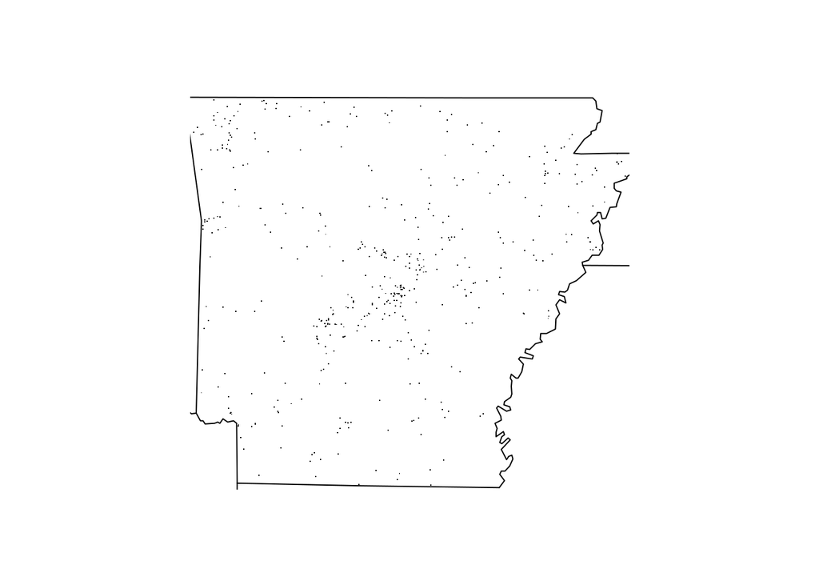

```r
fars_map_state(state.num=5, year=2013)
```